# Linear Mixed Models

Impact of Age and Education on Clinical Dementia Rating (CDR)

Author

Bess Tyler (Advisor: Dr. Seals)

Published

December 1, 2024

## Introduction

As the population of older adults continues to increase globally, cognitive decline has become a significant concern, impacting not only the individuals affected but also their families and society as a whole. The factors contributing to cognitive deterioration are multifaceted, including age, health conditions, lifestyle choices, socioeconomic status, and more. Understanding the interaction of these influences is crucial for effectively addressing the issue. Traditional statistical techniques often struggle to capture these complex relationships, which limits their ability to provide a comprehensive perspective on cognitive aging [4,6].

An effective approach to this challenge is the use of Linear Mixed Models (LMMs), which enable a more sophisticated analysis of complex data structures. These models can account for both fixed effects, which reflect general trends within populations, and random effects, which capture individual variability [2,6]. This characteristic makes LMMs particularly valuable for the analysis of longitudinal data, where multiple observations are collected over time [3]. By employing LMMs, we can more thoroughly investigate how different factors influence cognitive function [1, 5].

The objective of this study is to utilize LMMs to explore the relationship between cognitive decline and various demographic and health-related variables, with a specific focus on Clinical Dementia Rating (CDR) as an indicator of cognitive performance. By analyzing the interactions between different factors, we aim to develop a clearer understanding of the elements that contribute to cognitive aging and how these differ across populations [7].

## Methods

Bates stated that ” A linear mixed model is described by the distribution of two vector-valued random variables: Y, the response, and beta , the vector of random effects. [2]

LMMs are particularly appropriate for this study because cognitive decline in older adults is often heterogeneous, meaning that individuals may experience different rates of decline over time. The inclusion of random effects enables the model to account for this variability, which is crucial for accurately capturing individual trajectories of cognitive change [7]. Additionally, the use of LMMs helps to mitigate potential biases from missing data, which is common in longitudinal studies, by allowing for more flexible handling of incomplete observations [3, 4].

### Model Specification

The model structure is as follows:

$Y_{ij} = \beta_0 + \beta_{1ij} + u_{0j} + \epsilon_{ij}$

Where:

- $\text{Y}_{ij}$ is the response for observation $i$ for subject $j$
- $\text{Age}_{ij}$ represents the fixed effect of age
- $u_{0j}$ is the random effect for subject $j$ (accounting for individual variability in cognitive decline)
- $\epsilon_{ij}$ is the residual error term

### Assumptions

- Linearity - The relationship between the dependent variable and the predictors is assumed to be linear.
- Normality - The residuals are assumed to follow a normal distribution.
- Independence - Residuals should be independent across observations.
- Homoscedasticity - The variance of the residuals should be constant across all levels of the fixed predictors.

## Analysis and Results

### Data Collection

Data was collected from OASIS Longitudinal Dataset, which included a sample of adults aged 60 - 96. The dataset comprised of 150 participants. Cognitive function was assessed using Clinical Dementia Rating, while predictors included age, dementia status, and relevant socioeconomic factors.

### Data Exploration and Visualization

- Dataset: OASIS-Longitudinal MRI Data in Nondemented and Demented Older Adults
  - Source: [NCBI](https://www.ncbi.nlm.nih.gov/pmc/articles/PMC2895005/)

  **Summary of the chosen dataset:**
  - Includes MRI scans of 150 subjects aged 60-96.
  - Longitudinal data collected over 373 sessions.
  - Subjects scanned at least twice, with visits separated by at least a year.
  - Clinical Dementia Rating (CDR) categorized as nondemented or with mild Alzheimer’s disease.
  - 72 were nondemented throughout, while 64 were demented initially and remained so.
  - Participants were right-handed, consisting of 62 men and 88 women.
  - Each session had 3-4 T1-weighted MRI scans.

  Table 1 for this dataset can be seen below:

  ```
                    Stratified by Group
                     level  Converted        Demented         Nondemented
    n                            37              146              190
    Age (mean (SD))           79.76 (7.43)     76.26 (6.94)     77.06 (8.10)
    Gender (%)       Female      24 ( 64.9)       60 ( 41.1)      129 ( 67.9)
                     Male        13 ( 35.1)       86 ( 58.9)       61 ( 32.1)
    Hand (%)         R           37 (100.0)      146 (100.0)      190 (100.0)
    EDUC (mean (SD))          15.46 (2.52)     13.67 (2.90)     15.14 (2.74)
    SES (mean (SD))            1.73 (0.96)      2.77 (1.20)      2.39 (1.05)
    MMSE (mean (SD))          28.68 (1.56)     24.51 (4.50)     29.23 (0.88)
    CDR (%)          0           18 ( 48.6)        0 (  0.0)      188 ( 98.9)
                     0.5         19 ( 51.4)      102 ( 69.9)        2 (  1.1)
                     1            0 (  0.0)       41 ( 28.1)        0 (  0.0)
                     2            0 (  0.0)        3 (  2.1)        0 (  0.0)
    eTIV (mean (SD))        1459.27 (135.43) 1485.85 (173.77) 1495.50 (184.89)
    nWBV (mean (SD))           0.72 (0.04)      0.72 (0.03)      0.74 (0.04)
    ASF (mean (SD))            1.21 (0.11)      1.20 (0.14)      1.19 (0.14)
                    Stratified by Group
                     p      test SMD
    n
    Age (mean (SD))   0.045       0.313
    Gender (%)       <0.001       0.371

    Hand (%)             NA      <0.001
    EDUC (mean (SD)) <0.001       0.433
    SES (mean (SD))  <0.001       0.652
    MMSE (mean (SD)) <0.001       1.041
    CDR (%)          <0.001       5.599



    eTIV (mean (SD))  0.510       0.149
    nWBV (mean (SD)) <0.001       0.465
    ASF (mean (SD))   0.683       0.111
  ```

  The age distribution of participants is displayed in the visual below:

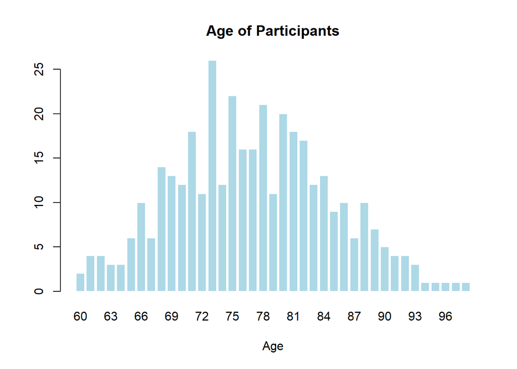

The distribution of participants’ education levels is presented in the visual below:

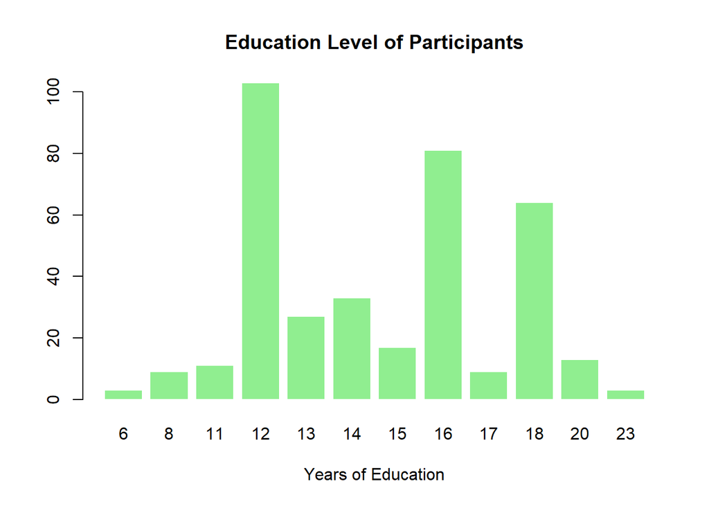

### Modeling and Results

#### Data Processing and Cleaning

```r
#install.packages("readr")
library(readr)

oasis_data <- read_csv("oasis_longitudinal.csv")

# Remove duplicate rows
oasis_data <- oasis_data[!duplicated(oasis_data), ]

# Remove rows with missing values
oasis_data <- na.omit(oasis_data)

# View cleaned data
head(oasis_data)
```

```
# A tibble: 6 × 15
  `Subject ID` `MRI ID`     Group Visit `MR Delay` `M/F` Hand    Age  EDUC   SES
  <chr>        <chr>        <chr> <dbl>      <dbl> <chr> <chr> <dbl> <dbl> <dbl>
1 OAS2_0001    OAS2_0001_M… Nond…     1          0 M     R        87    14     2
2 OAS2_0001    OAS2_0001_M… Nond…     2        457 M     R        88    14     2
3 OAS2_0004    OAS2_0004_M… Nond…     1          0 F     R        88    18     3
4 OAS2_0004    OAS2_0004_M… Nond…     2        538 F     R        90    18     3
5 OAS2_0005    OAS2_0005_M… Nond…     1          0 M     R        80    12     4
6 OAS2_0005    OAS2_0005_M… Nond…     2       1010 M     R        83    12     4
# ℹ 5 more variables: MMSE <dbl>, CDR <dbl>, eTIV <dbl>, nWBV <dbl>, ASF <dbl>
```

The data processing and cleaning steps involved in the provided R code are as follows:

1. **Loading the Data**:  
   The first step is loading the necessary library readr, which is used to read CSV files efficiently. The read_csv() function is used to import the dataset named oasis_longitudinal.csv into R and store it in oasis_data.
2. **Removing Duplicate Rows**:  
   The line oasis_data <- oasis_data[!duplicated(oasis_data), ] is used to remove duplicate rows from the dataset. The duplicated() function checks for duplicate rows, and the ! operator negates it, keeping only the unique rows. This ensures that any repeated data points are eliminated, preventing redundancy in the analysis.
3. **Removing Rows with Missing Values**:  
   The na.omit(oasis_data) function is applied to remove any rows that contain missing values (NA). This step ensures that the dataset is complete for analysis and avoids errors that may arise when handling missing data. It eliminates any rows where at least one variable has a missing value.
4. **Viewing the Cleaned Data**:  
   Finally, the head(oasis_data) function is used to display the first few rows of the cleaned dataset. This helps the user confirm that the data has been processed and cleaned correctly, and it allows for a quick visual inspection of the cleaned data.

Overall, these steps ensure that the dataset is free of duplicates and missing values, making it ready for further analysis.

## Linear Mixed Modeling

### **Model 1**

For the first model, we examined age as the sole predictor of CDR. The linear mixed model used for model 1 is given by:

$$\text{CDR}{ij} = \beta_0 + \beta_1 \cdot \text{AGE}{ij} + \mu_{i} + \epsilon_{ij}$$

```r
#install.packages("lme4")

library(lme4)
oasis_data$SubjectID <- oasis_data$'Subject ID'
oasis_data$Age <- as.numeric(as.character(oasis_data$Age))

# Fit the linear mixed model with only Age as the predictor
model <- lmer(CDR ~ Age + (1 | SubjectID), data = oasis_data)
summary(model)
```

```
Linear mixed model fit by REML ['lmerMod']
Formula: CDR ~ Age + (1 | SubjectID)
   Data: oasis_data

REML criterion at convergence: 69.6

Scaled residuals:
    Min      1Q  Median      3Q     Max
-2.5221 -0.1926 -0.0748  0.1252  3.8510

Random effects:
 Groups    Name        Variance Std.Dev.
 SubjectID (Intercept) 0.12242  0.3499
 Residual              0.02456  0.1567
Number of obs: 354, groups:  SubjectID, 142

Fixed effects:
             Estimate Std. Error t value
(Intercept) -0.219460   0.246723  -0.889
Age          0.006635   0.003183   2.085

Correlation of Fixed Effects:
    (Intr)
Age -0.992
```

$$\text{CDR}{ij} = -.2195 + 0.0066 \cdot \text{AGE}{ij} + \mu_{i} + \epsilon_{ij}$$

**INTERPRETATION:**

The fixed effect of age shows a positive estimate of 0.0066, suggesting that as age increases, the CDR score also tends to increase, indicating greater cognitive decline. The t-value of 2.085 suggests that this effect of age on cognitive decline is statistically significant. The intercept of -0.219 and a t-value of -0.889, indicates the baseline CDR score when age=0 . Although age can not possibly be 0, it provides a reference point for the model. This equation shows us that age has a statistically significant positive relationship with CDR, suggesting that cognitive decline tends to increase slightly with age.

### **Model 2**

For the second model, we expanded our model to include Education Level (EDUC) as an additional predictor. The linear mixed model used for model 2 is given by:

$$\text{CDR}{ij} = \beta_0 + \beta_1 \cdot \text{AGE}{ij} + \beta_2 \cdot \text{EDUC}{ij} + \mu_{i} + \epsilon_{ij}$$

```r
oasis_data$Age <- as.numeric(as.character(oasis_data$Age))
# Fit Linear Mixed Model with Age and Education as the predictors
model <- lmer(CDR ~ Age + EDUC + (1 | SubjectID), data = oasis_data)
summary(model)
```

```
Linear mixed model fit by REML ['lmerMod']
Formula: CDR ~ Age + EDUC + (1 | SubjectID)
   Data: oasis_data

REML criterion at convergence: 74.5

Scaled residuals:
    Min      1Q  Median      3Q     Max
-2.4880 -0.1874 -0.0707  0.1154  3.9072

Random effects:
 Groups    Name        Variance Std.Dev.
 SubjectID (Intercept) 0.1208   0.3476
 Residual              0.0246   0.1568
Number of obs: 354, groups:  SubjectID, 142

Fixed effects:
             Estimate Std. Error t value
(Intercept)  0.040317   0.295446   0.136
Age          0.006377   0.003174   2.009
EDUC        -0.016376   0.010542  -1.553

Correlation of Fixed Effects:
     (Intr) Age
Age  -0.846
EDUC -0.555  0.039
```

$$\text{CDR}{ij} = 0.0403 + 0.0064 \cdot \text{Age}{ij} - 0.0164 \cdot \text{EDUC}{ij} + \mu_{i} + \epsilon_{ij}$$

**INTERPRETATION:**

The fixed effect of age is statistically significant, with an estimate of 0.0064 (t = 2.009), suggesting that as age increases, cognitive decline, as measured by CDR, also tends to increase. This positive relationship indicates that older participants generally exhibit higher CDR scores, reflecting more cognitive decline. In contrast, the fixed effect of Education Level is not statistically significant, with an estimate of -0.0164 and a t-value of -1.553. This suggests that education level, as measured here, does not show a strong or significant relationship with cognitive decline in this model.

## Conclusion

The results for my analysis reveal age has a statistically significant effect on Clinical Dementia Rating, with older age associated with slightly higher dementia severity. Education, while included as a predictor, does not show a significant effect on CDR in this model. This suggests that age is a more important factor in cognitive decline, but Education might not be as influential in this specific dataset.

Linear Mixed Models offer a powerful and flexible approach to analyzing complex data structures that involve both fixed and random effects. They allow for more accurate conclusions in the presence of correlations and varying group-level effects, making them indispensable for research in many fields [1, 2, 4, 5].

## References

[1]Agostinelli, C., & Yohai, V. J. (2016). Composite robust estimators for linear mixed models. *Journal of the American Statistical Association*, 111(516), 1764-1774. https://doi.org/10.1080/01621459.2015.1115358

[2]Bates, D., Mächler, M., Bolker, B., and Walker, S. (2015), “Fitting Linear Mixed- Effects Models Using lme4,” *Journal of Statistical Software*, 67, 1–48. https://doi.org/10.18637/jss.v067.i01.

[3]Booth, J. G., & Hobert, J. P. (1998). Standard Errors of Prediction in Generalized Linear Mixed Models. *Journal of the American Statistical Association*, *93*(441), 262–272. https://www.tandfonline.com/doi/abs/10.1080/01621459.1998.10474107

[4]Brown, V. A. (2021). An introduction to linear mixed-effects modeling in R. *Advances in Methods and Practices in Psychological Science, 4*(1), 1–19. https://doi.org/10.1177/2515245920960351

[5]McCulloch, C. E. (1996). An introduction to generalized linear mixed models. In *NSF-CBMS Regional Conference Series in Probability and Statistics* (Vol. 7). https://doi.org/10.1214/lnms/1215451825

[6]Sinha, S. K. (2004). Robust Analysis of Generalized Linear Mixed Models. *Journal of the American Statistical Association*, *99*(466), 451–460. https://doi.org/10.1198/016214504000000340

[7]Starkweather, J. (2010). Linear mixed effects modeling using R. *Unpublished Manuscript*. https://doi.org/10.13140/RG.2.1.3420.4240